# Text, Labels, & Tables (Illustration)

Author

Affiliation

Yasmeen R’ghioui

George Washington University

Published

March 14, 2026

## 1) Environment Setup

**Description**: This dataset was sourced from the Data World website and was created by Kristian Reynolds. It was last updated 8 years ago. This dataset is a collection of 88 end-of-game Fortnite Statistics. Additional data includes time of day, date, and mental state.

```python
import numpy as np
import pandas as pd
import matplotlib.pyplot as plt
import seaborn as sns
import plotly.express as px
from sklearn.datasets import load_iris
import calendar
data = pd.read_csv("Fortnite_Statistics.csv")
```

## 2) Correlation between Mental State and Game Placement

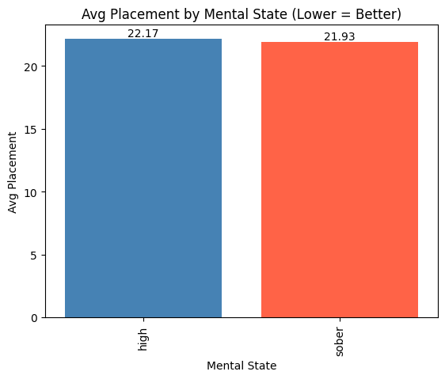

```python
# Bar plot: Mental State vs In-game Placement
avg_placement = data.groupby("Mental State")["Placed"].mean()

ax = avg_placement.plot(kind='bar')
ax.bar_label(ax.containers[0], fmt='%.2f')

plt.bar(avg_placement.index, avg_placement.values, color=["steelblue", "tomato"])
plt.title("Avg Placement by Mental State (Lower = Better)")
plt.xlabel("Mental State")
plt.ylabel("Avg Placement")
plt.show()
```

## 3) Mental State Game Averages

```python
fortnite = pd.DataFrame({
    'Mental State': data['Mental State'].unique(),
    'Avg Placement': data.groupby('Mental State')['Placed'].mean().round(2).values,
    'Avg Eliminations': data.groupby('Mental State')['Eliminations'].mean().round(2).values,
    'Avg Headshots': data.groupby('Mental State')['Head Shots'].mean().round(2).values,
})

fortnite['Placement Diff'] = fortnite['Avg Placement'].diff().round(2)
fortnite = fortnite.sort_values('Avg Placement', ascending=True).reset_index(drop=True)
fortnite
```

[output not shown]

## 4) Game Eliminations vs Damage to Players

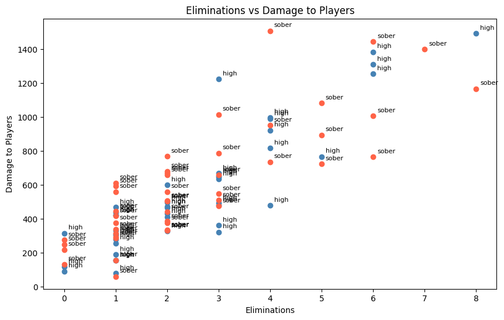

```python
colors = {'sober': 'tomato', 'high': 'steelblue'}

plt.figure(figsize=(10, 6))

for state, group in data.groupby('Mental State'):
    plt.scatter(group['Eliminations'], group['Damage to Players'],
                color=colors[state], label=state)

for idx, row in data.iterrows():
    plt.annotate(row['Mental State'],
                 xy=(row['Eliminations'], row['Damage to Players']),
                 xytext=(5, 5),
                 textcoords='offset points',
                 fontsize=8)

plt.title("Eliminations vs Damage to Players")
plt.xlabel("Eliminations")
plt.ylabel("Damage to Players")
plt.show()
```

```python
fortnite = data.groupby(['Eliminations', 'Mental State'])['Damage to Players'].mean().round(2).reset_index()
fortnite.columns = ['Eliminations', 'Mental State', 'Avg Damage to Players']
fortnite = fortnite.sort_values('Avg Damage to Players', ascending=False).reset_index(drop=True)
fortnite
```

|  | Eliminations | Mental State | Avg Damage to Players |
| --- | --- | --- | --- |
| 0 | 8 | high | 1492.00 |
| 1 | 7 | sober | 1399.00 |
| 2 | 6 | high | 1314.67 |
| 3 | 8 | sober | 1166.00 |
| 4 | 6 | sober | 1071.00 |
| 5 | 4 | sober | 1064.33 |
| 6 | 5 | sober | 899.67 |
| 7 | 4 | high | 840.60 |
| 8 | 5 | high | 766.00 |
| 9 | 3 | sober | 665.33 |
| 10 | 3 | high | 608.67 |
| 11 | 2 | sober | 517.67 |
| 12 | 2 | high | 457.71 |
| 13 | 1 | sober | 370.50 |
| 14 | 1 | high | 292.85 |
| 15 | 0 | sober | 219.25 |
| 16 | 0 | high | 174.33 |

## 5) Reflection

For my visualizations, I made deliberate labeling and design choices to ensure clarity and accurate interpretation. In the bar chart comparing average placement by mental state, I used bar_label() to display the exact averages directly above each bar, removing the need for the viewer to estimate values from the y-axis. I also noted “Lower = Better” in the title since placement in Fortnite is inversely scaled. Without that context, a shorter bar could be misread as worse performance. The colors steelblue and tomato were chosen to give each mental state a distinct, easily distinguishable identity that consistently carries into the scatter plot.